# Brain Age Longitudinal PACC

Jorge Garcia Condado

2025-11-26

We will explore how baseline Brain Age delta moderates longitudinal PACC through a linear mixed effects model on four cohorts: - A4/LEARN - HABS - ADNI CU - ADNI MCI

# A4

## Trajectories

Plot individual PACC trajectories with spaghetti plot.

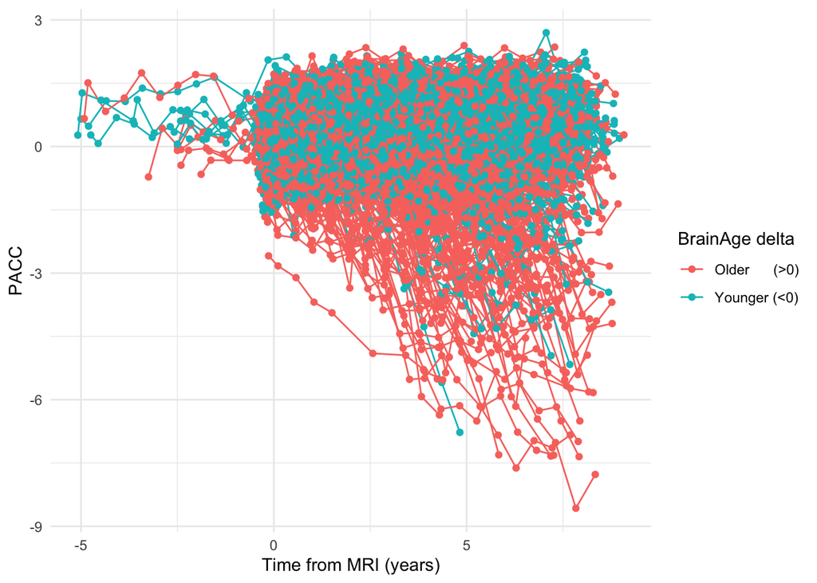

## Mixed Effects Model

Simplest Quadratic mixed effects models with delta interaction:

PACC ~ time_mri^2 + time_mriXdelta + Cumulative_Dose_Scaled + LMSTORY + time_mriXcohort

```
## Delta effect: -0.13 [ -0.16 , -0.11 ]  p-val: 2.4e-31
```

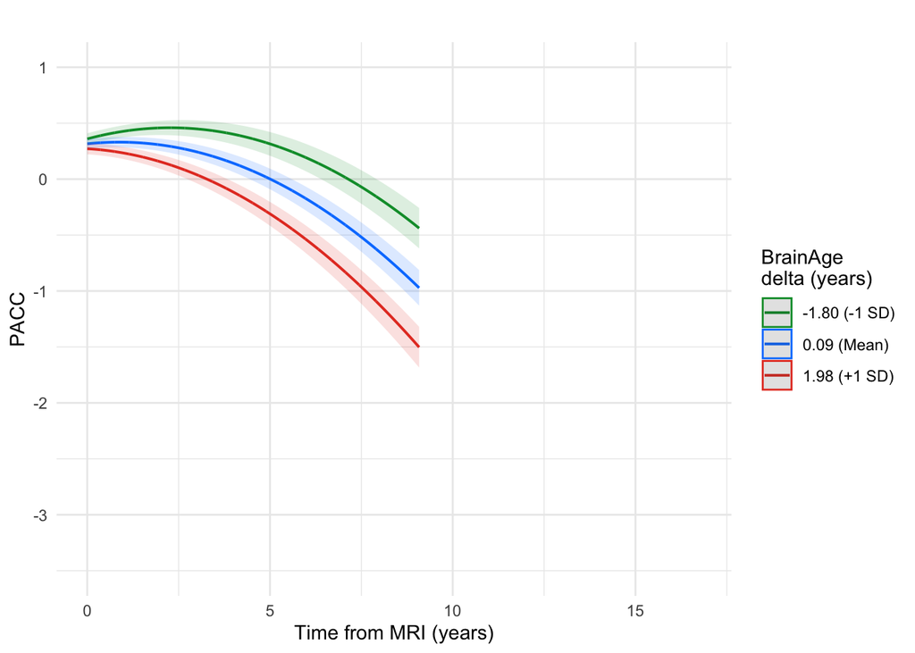

## Sensitivity Analysis

### Linear vs Quadratic

```
## Linear vs Quadratic p-value: 2.103132e-225
```

### Placebo

```
## Placebo estimated coefficient: -0.1551076
```

```
## Using placebo data p-value: 4.106173e-15
```

### Age, e4 and amyloid

Amyloid is not included because cohort already takes this into account as LEARN are those that are ab- compared to A4 which are ab+. This leads to singularity back solve if ab_status included.

Add Age, APOE, Sex, Education:

```
## Adding demographics estimated coefficient: -0.1338491
```

```
## Adding demographcis p-value: 3.591945e-27
```

### Change from baseline

Changing the model’s outcome to be change from baseline PACC and adding baseline PACC as covariate as well as the other covariates.

```
## Change from baseline estimated coefficient: -0.108671
```

```
## Change from baseline p-value: 8.000335e-22
```

## Interactions

### AB-PET

```
## BrainAge delta * AB effect: -0.08 [ -0.1 , -0.06 ]  p-val: 9.1e-15
```

```
## BrainAge delta effect: -0.1152364 p-val 0.2389577
```

```
## AB-PET effect: -0.1711032 p-val 7.876463e-26
```

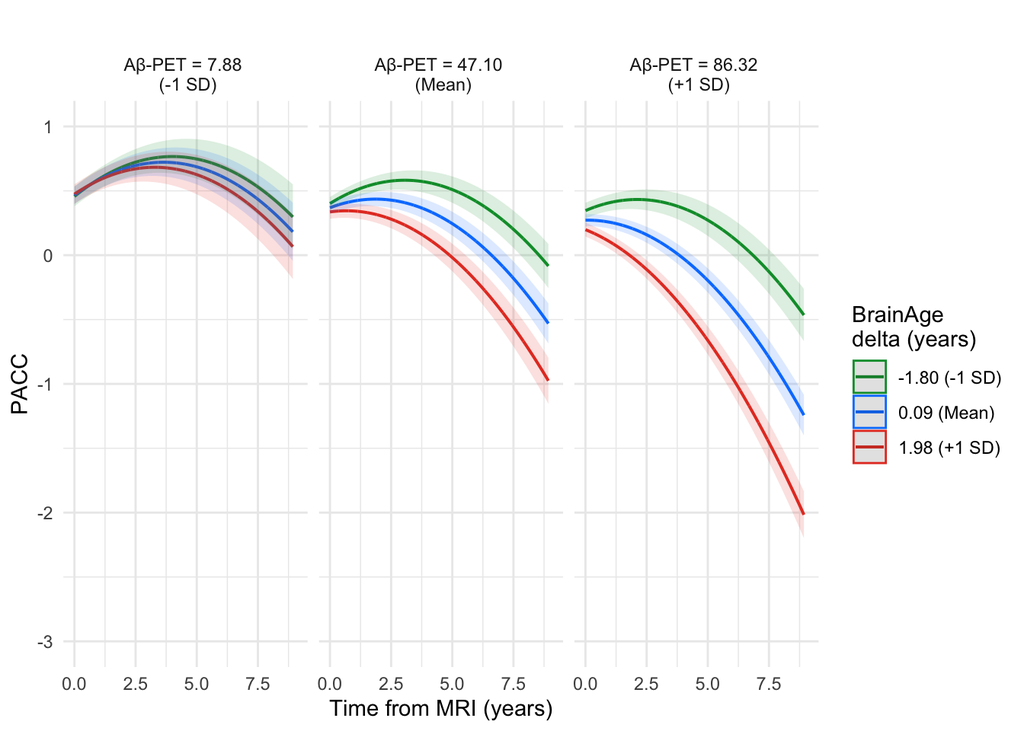

Adding Age, Sex, Education, E4 Status as covariates

```
## Adding demographics estimated coefficient: -0.07723652
```

```
## Adding gemographcis p-value: 7.175197e-14
```

Keeping only participants with Aβ-PET within 1 year of MRI.

```
## Adding demographics and only particiapnts within 1 year of MRI estimated coefficient: -0.07599732
```

```
## Participants within 1 year p-value: 1.316486e-13
```

### pTau217

```
## BrainAge delta * pTau217 effect: -0.082 [ -0.12 , -0.043 ]  p-val: 3.7e-05
```

```
## BrainAge delta effect: -0.1385027 p-val 0.6917959
```

```
## pTau217 effect: -0.1516978 p-val 1.948391e-09
```

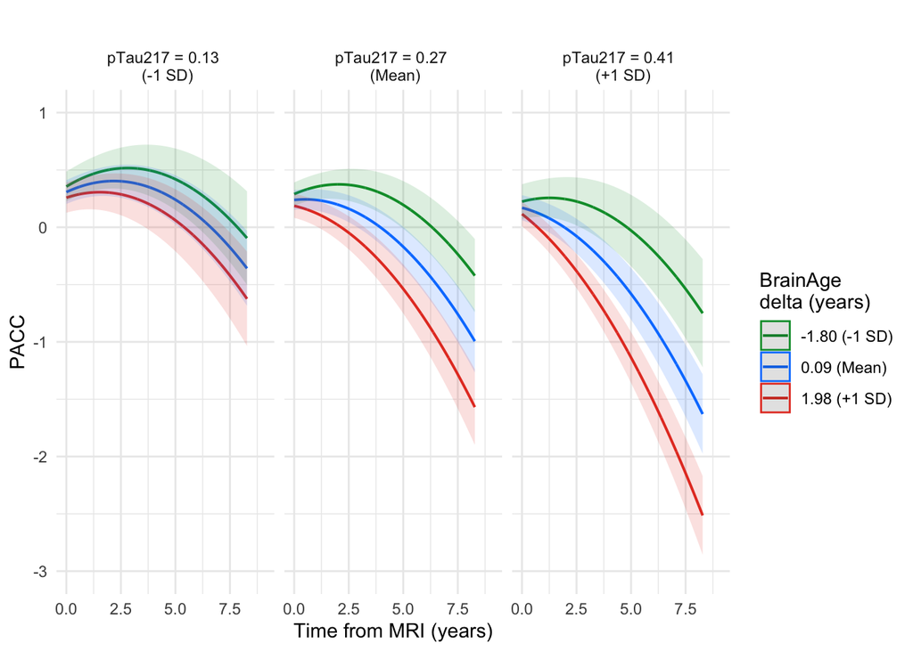

Adding Age, Sex, Education, E4 Status as covariates

```
## Adding demographics estimated coefficient: -0.08280586
```

```
## Adding gemographcis p-value: 2.820792e-05
```

Keeping only participants with ptau217 within 1 year of MRI.

```
## Adding demographics and only particiapnts within 1 year of MRI estimated coefficient: -0.08249384
```

```
## Participants within 1 year p-value: 2.839139e-05
```

### Tau-PET

```
## BrainAge delta * tau217 effect: -0.04 [ -0.074 , -0.0066 ]  p-val: 0.019
```

```
## BrainAge delta effect: -0.07947587 p-val 0.1136393
```

```
## Tau-PET effect: -0.2666492 p-val 6.617619e-29
```

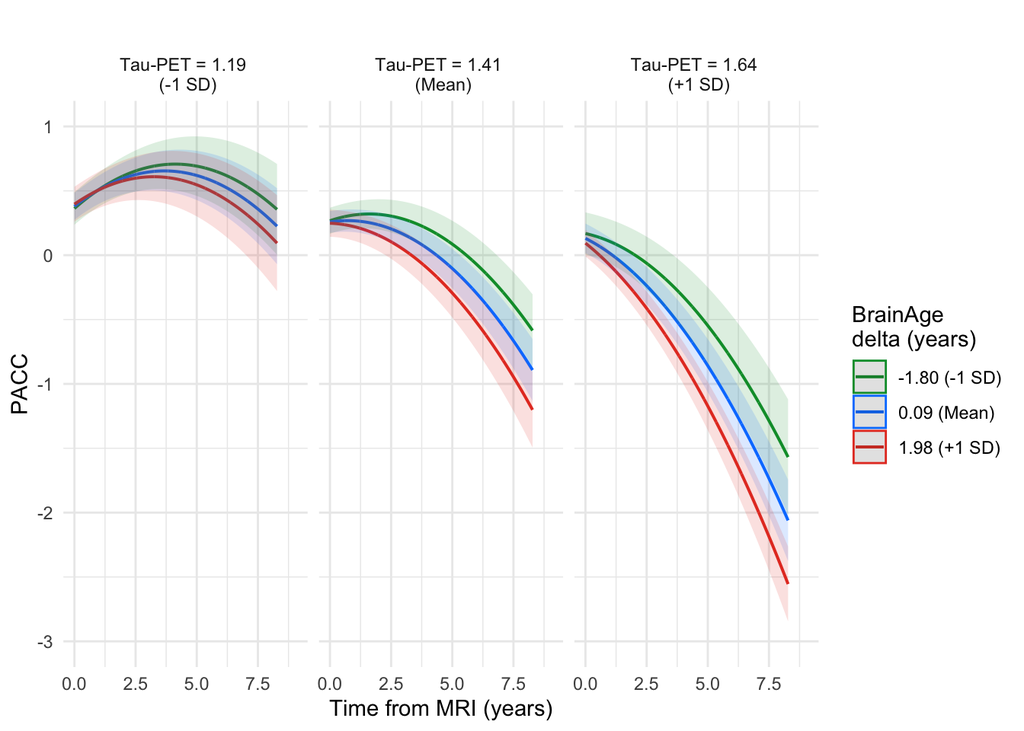

Adding Age, Sex, Education, E4 Status as covariates

```
## Adding demographics estimated coefficient: -0.04179501
```

```
## Adding gemographcis p-value: 0.01552705
```

Keeping only participants with Tau-PET within 1 year of MRI.

```
## Adding demographics and only particiapnts within 1 year of MRI estimated coefficient: -0.04066546
```

```
## Participants within 1 year p-value: 0.01678838
```

# HABS

## Trajectories

Plot individual PACC trajectories with spaghetti plot.

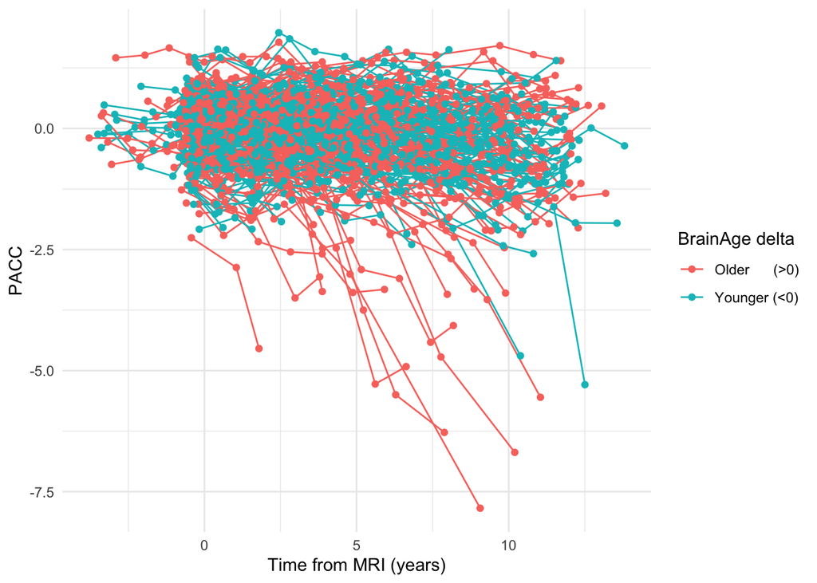

## Mixed Effects Model

Simplest Quadratic mixed effects models with delta interaction:

PACC ~ time_mri^2 + time_mriXdelta

```
## Delta effect: -0.19 [ -0.25 , -0.12 ]  p-val: 2e-08
```

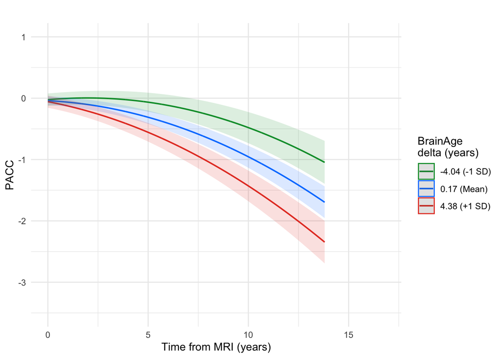

## Sensitivity Analysis

### Linear vs Quadratic

```
## Linear vs Quadratic p-value: 1.135385e-29
```

### Age, e4 and amyloid

Add Age, AB_status, APOE, Sex, Education:

```
## Adding demographics estimated coefficient: -0.1619889
```

```
## Adding gemographcis p-value: 2.151955e-08
```

### Change from baseline

Changing the model’s outcome to be change from baseline PACC and adding baseline PACC as covariate as well as the other covariates.

```
## Change from baseline estimated coefficient: -0.1298601
```

```
## Change from baseline p-value: 8.483627e-07
```

## Interactions

### AB-PET

```
## BrainAge delta * AB effect: -0.14 [ -0.19 , -0.09 ]  p-val: 7.7e-08
```

```
## BrainAge delta effect: -0.1238888 p-val 0.692033
```

```
## AB-PET effect: -0.2553744 p-val 1.28444e-18
```

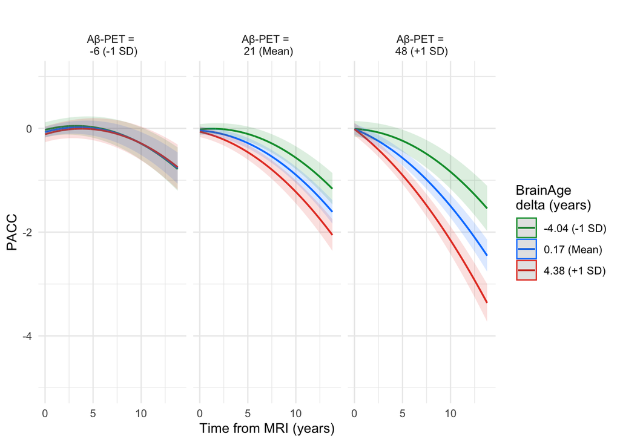

Adding Age, Sex, Education, E4 Status as covariates

```
## Adding demographics estimated coefficient: -0.1431507
```

```
## Adding gemographcis p-value: 1.729161e-08
```

Keeping only participants with Aβ-PET within 1 year of MRI.

```
## Adding demographics and only particiapnts within 1 year of MRI estimated coefficient: -0.1424051
```

```
## Participants within 1 year p-value: 1.672194e-08
```

### pTau217

```
## BrainAge delta * pTau217 effect: -0.1 [ -0.15 , -0.051 ]  p-val: 7.9e-05
```

```
## BrainAge delta effect: -0.1137161 p-val 0.8075654
```

```
## pTau217 effect: -0.2524029 p-val 1.239013e-15
```

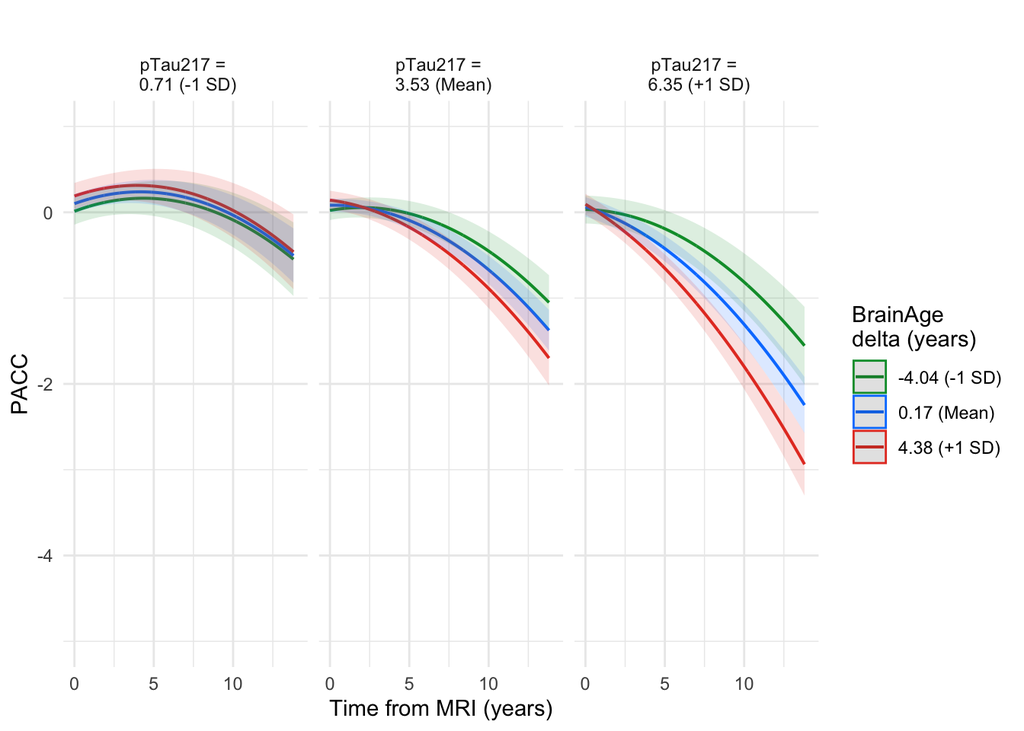

Adding Age, Sex, Education, E4 Status as covariates

```
## Adding demographics estimated coefficient: -0.09989929
```

```
## Adding gemographcis p-value: 6.028792e-05
```

Keeping only participants with pTau217 within 1 year of MRI.

```
## Adding demographics and only particiapnts within 1 year of MRI estimated coefficient: -0.09607232
```

```
## Participants within 1 year p-value: 0.0001538245
```

### Tau-PET

```
## BrainAge delta * Tau-PET effect: -0.16 [ -0.21 , -0.11 ]  p-val: 2.1e-10
```

```
## BrainAge delta effect: -0.08404526 p-val 8.317191e-09
```

```
## Tau-PET effect: -0.266444 p-val 3.759346e-22
```

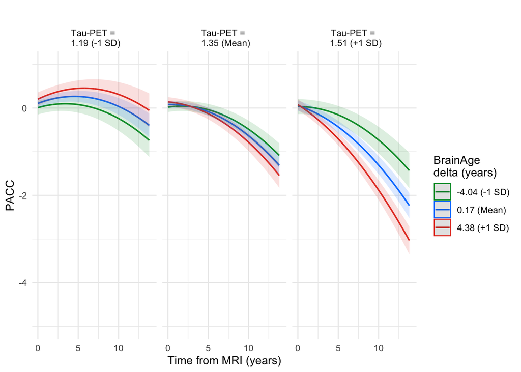

Adding Age, Sex, Education, E4 Status as covariates

```
## Adding demographics estimated coefficient: -0.1523043
```

```
## Adding gemographcis p-value: 1.318138e-09
```

Keeping only participants with Tau-PET within 1 year of MRI.

```
## Adding demographics and only particiapnts within 1 year of MRI estimated coefficient: -0.09506168
```

```
## Participants within 1 year p-value: 0.002124821
```

# ADNI CU

## Trajectories

Plot individual PACC trajectories with spaghetti plot.

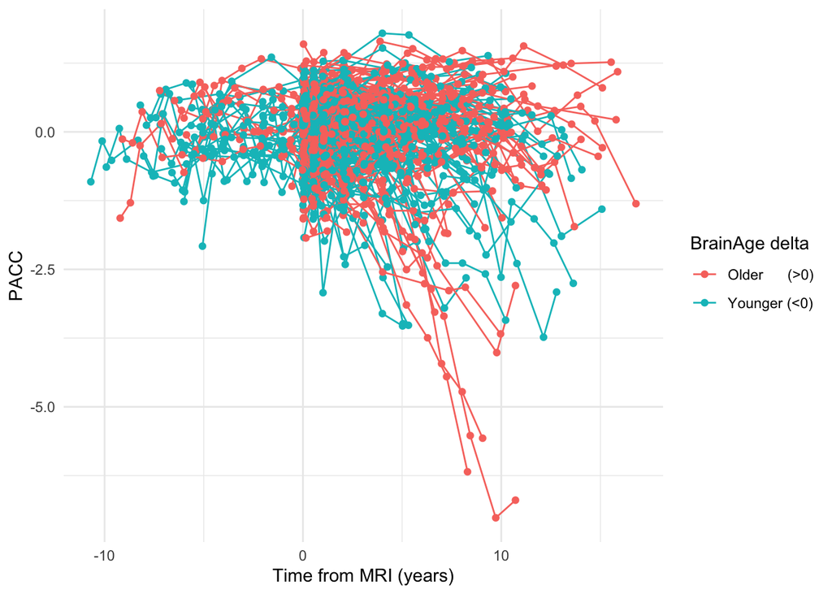

## Mixed Effects Model

Simplest Quadratic mixed effects models with delta interaction:

PACC ~ time_mri^2 + time_mriXdelta

```
## Delta effect: -0.06 [ -0.14 , 0.018 ]  p-val: 0.13
```

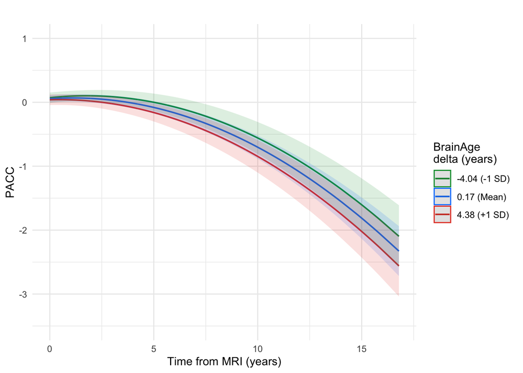

## Sensitivity Analysis

### Linear vs Quadratic

```
## Linear vs Quadratic p-value: 1.604416e-34
```

### Age, e4 and amyloid

Add Age, AB_status, APOE, Sex, Education:

```
## Adding demographics estimated coefficient: -0.07607362
```

```
## Adding gemographcis p-value: 0.04307728
```

### Change from baseline

Changing the model’s outcome to be change from baseline PACC and adding baseline PACC as covariate as well as the other covariates.

```
## Change from baseline estimated coefficient: -0.0687274
```

```
## Change from baseline p-value: 0.2274667
```

## Interactions

### AB-PET

```
## BrainAge delta * AB effect: -0.082 [ -0.14 , -0.023 ]  p-val: 0.0066
```

```
## BrainAge delta effect: -0.04730671 p-val 0.9729352
```

```
## AB-PET effect: -0.2511428 p-val 2.244352e-12
```

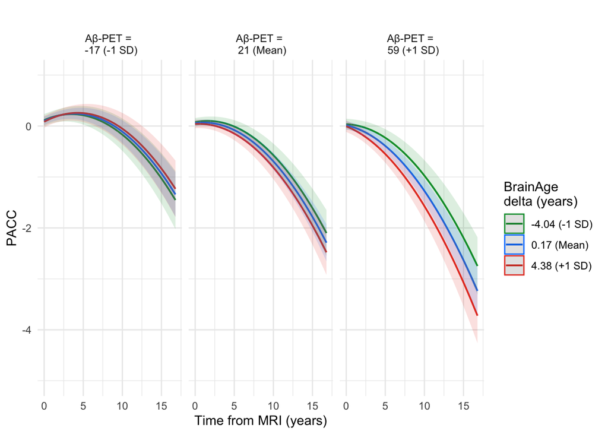

Adding Age, Sex, Education, E4 Status as covariates

```
## Adding demographics estimated coefficient: -0.09089808
```

```
## Adding gemographcis p-value: 0.002281148
```

Keeping only participants with Aβ-PET within 1 year of MRI.

```
## Adding demographics and only particiapnts within 1 year of MRI estimated coefficient: -0.07689109
```

```
## Participants within 1 year p-value: 0.06353713
```

### pTau217

```
## BrainAge delta * pTau217 effect: -0.031 [ -0.17 , 0.11 ]  p-val: 0.66
```

```
## BrainAge delta effect: -0.1491414 p-val 0.266085
```

```
## pTau217 effect: -0.3237629 p-val 2.979294e-06
```

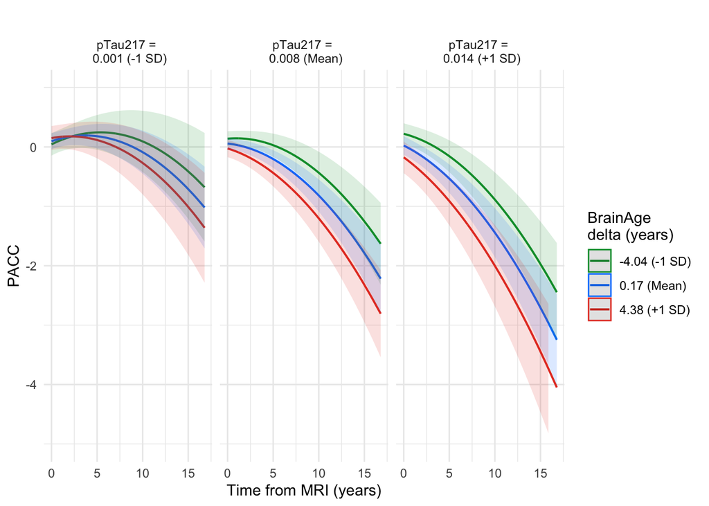

Adding Age, Sex, Education, E4 Status as covariates

```
## Adding demographics estimated coefficient: -0.04223502
```

```
## Adding gemographcis p-value: 0.542991
```

Keeping only participants with pTau217 within 1 year of MRI.

```
## Adding demographics and only particiapnts within 1 year of MRI estimated coefficient: 0.3156053
```

```
## Participants within 1 year p-value: 0.1161702
```

### Tau-PET

```
## BrainAge delta * tau217 effect: 0.02 [ -0.12 , 0.16 ]  p-val: 0.78
```

```
## BrainAge delta effect: -0.05364147 p-val 0.67397
```

```
## Tau-PET effect: -0.3393406 p-val 5.18895e-08
```

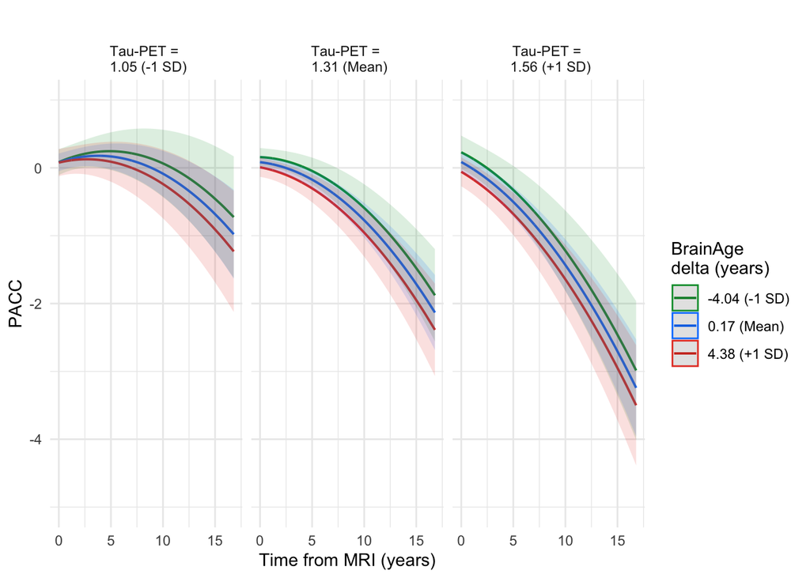

Adding Age, Sex, Education, E4 Status as covariates

```
## Adding demographics estimated coefficient: 0.0299743
```

```
## Adding gemographcis p-value: 0.6701048
```

Keeping only participants with Tau-PET within 1 year of MRI.

```
## Adding demographics and only particiapnts within 1 year of MRI estimated coefficient: 0.09882073
```

```
## Participants within 1 year p-value: 0.09062627
```

# ADNI MCI

## Trajectories

Plot individual PACC trajectories with spaghetti plot.

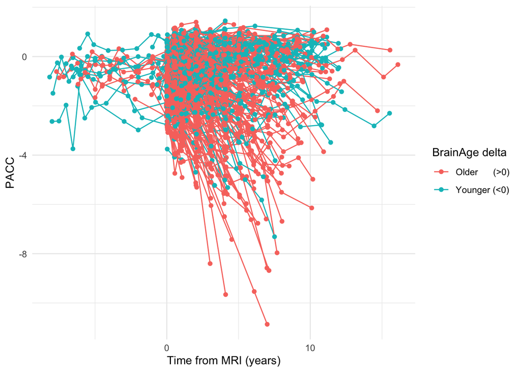

## Mixed Effects Model

Simplest Quadratic mixed effects models with delta interaction:

PACC ~ time_mri^2 + time_mriXdelta

```
## Delta effect: -0.31 [ -0.39 , -0.24 ]  p-val: 4.1e-16
```

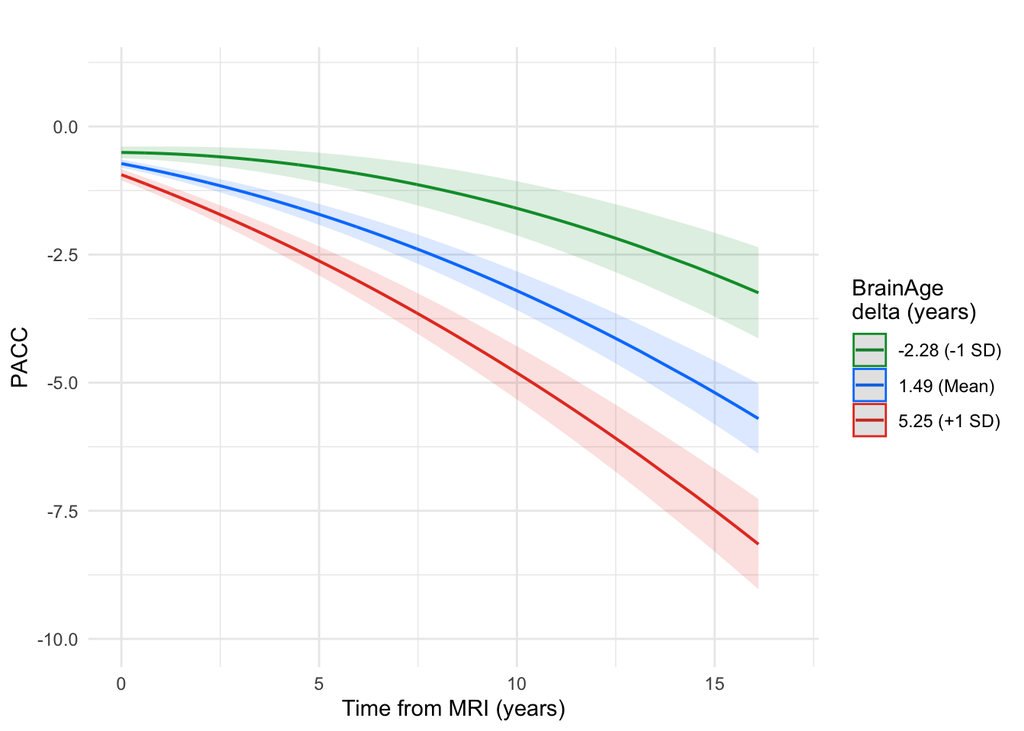

## Sensitivity Analysis

### Linear vs Quadratic

```
## Linear vs Quadratic p-value: 1.203515e-17
```

### Age, e4 and amyloid

Add Age, AB_status, APOE, Sex, Education:

```
## Adding demographics estimated coefficient: -0.28556
```

```
## Adding gemographcis p-value: 1.084173e-14
```

### Change from baseline

Changing the model’s outcome to be change from baseline PACC and adding baseline PACC as covariate as well as the other covariates.

```
## Change from baseline estimated coefficient: -0.3015663
```

```
## Change from baseline p-value: 7.848485e-09
```

## Interactions

### AB-PET

```
## BrainAge delta * AB effect: -0.11 [ -0.17 , -0.036 ]  p-val: 0.0031
```

```
## BrainAge delta effect: -0.2031691 p-val 0.01174901
```

```
## AB-PET effect: -0.3317746 p-val 7.104952e-13
```

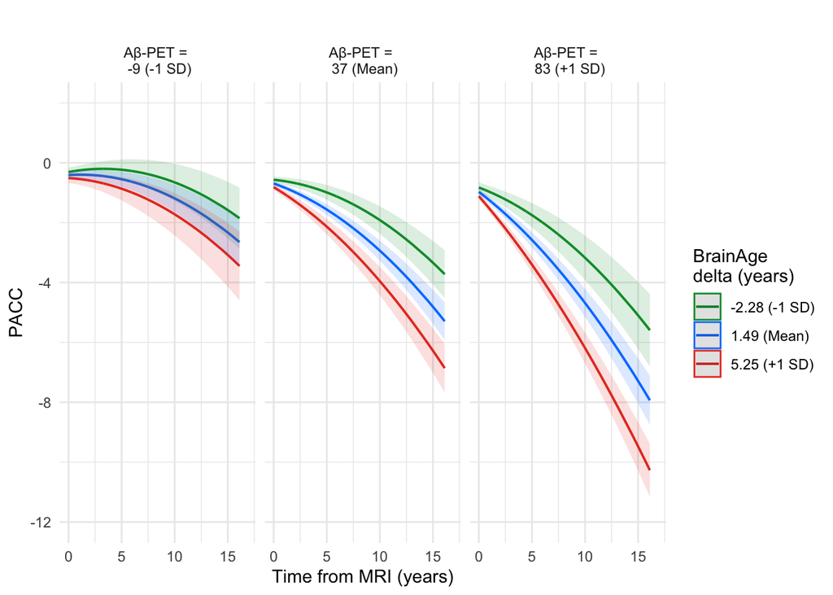

Adding Age, Sex, Education, E4 Status as covariates

```
## Adding demographics estimated coefficient: -0.1145484
```

```
## Adding gemographcis p-value: 0.001296245
```

Keeping only participants with Aβ-PET within 1 year of MRI.

```
## Adding demographics and only particiapnts within 1 year of MRI estimated coefficient: -0.132618
```

```
## Participants within 1 year p-value: 0.0001834934
```

### pTau217

```
## BrainAge delta * pTau217 effect: -0.26 [ -0.43 , -0.094 ]  p-val: 0.0027
```

```
## BrainAge delta effect: -0.1015306 p-val 0.1195543
```

```
## pTau217 effect: -0.2858083 p-val 0.01438463
```

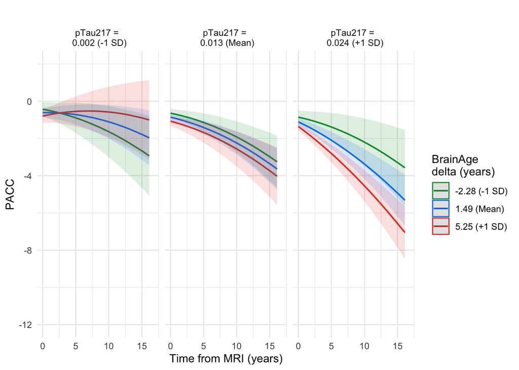

Adding Age, Sex, Education, E4 Status as covariates

```
## Adding demographics estimated coefficient: -0.2837596
```

```
## Adding gemographcis p-value: 0.003975296
```

Keeping only participants with pTau217 within 1 year of MRI.

```
## Adding demographics and only particiapnts within 1 year of MRI estimated coefficient: -0.1594625
```

```
## Participants within 1 year p-value: 0.4318319
```

### Tau-PET

```
## BrainAge delta * tau217 effect: -0.18 [ -0.4 , 0.035 ]  p-val: 0.1
```

```
## BrainAge delta effect: -0.07658245 p-val 0.1871747
```

```
## Tau-PET effect: -0.3496441 p-val 0.00505171
```

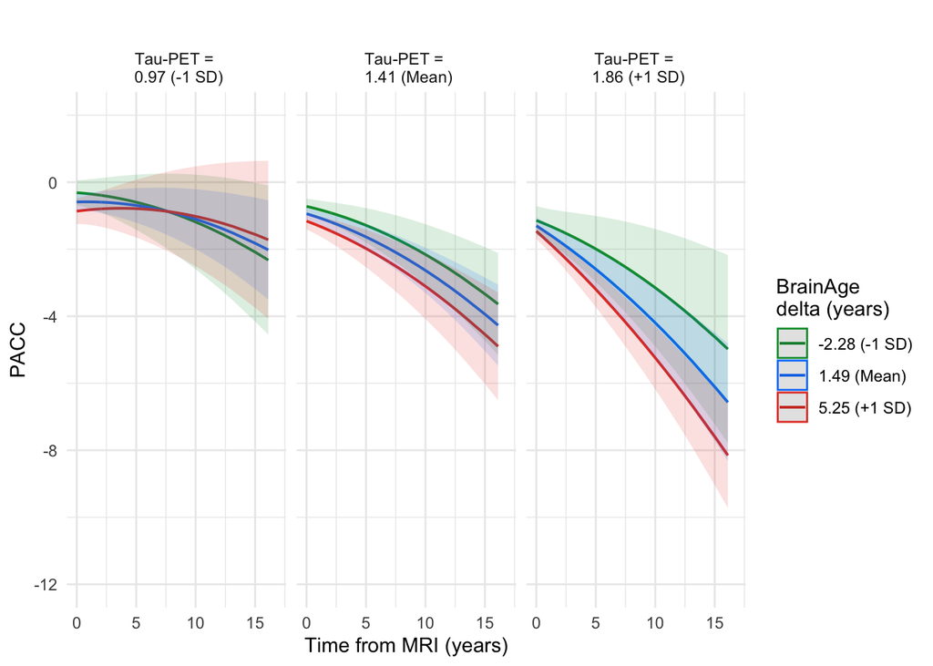

Adding Age, Sex, Education, E4 Status as covariates

```
## Adding demographics estimated coefficient: -0.1788944
```

```
## Adding gemographcis p-value: 0.1531457
```

Keeping only participants with Tau-PET within 1 year of MRI.

```
## Adding demographics and only particiapnts within 1 year of MRI estimated coefficient: -0.01118535
```

```
## Participants within 1 year p-value: 0.9067547
```

# Summary

Forest plots to summarize all the information of linear mixed effects models

## Delta

```
## All Cohorts BrainAge delta effect: -0.17 [ -0.34 , -0.006 ]  p-val: 0.046  I2: 89.5
```

```
## CU Cohorts BrainAge delta effect: -0.13 [ -0.21 , -0.057 ]  p-val: 0.018  I2: 0.00563
```

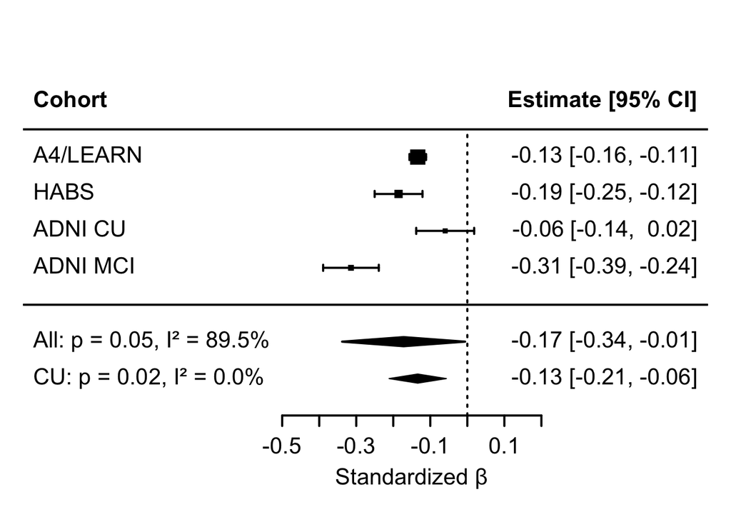

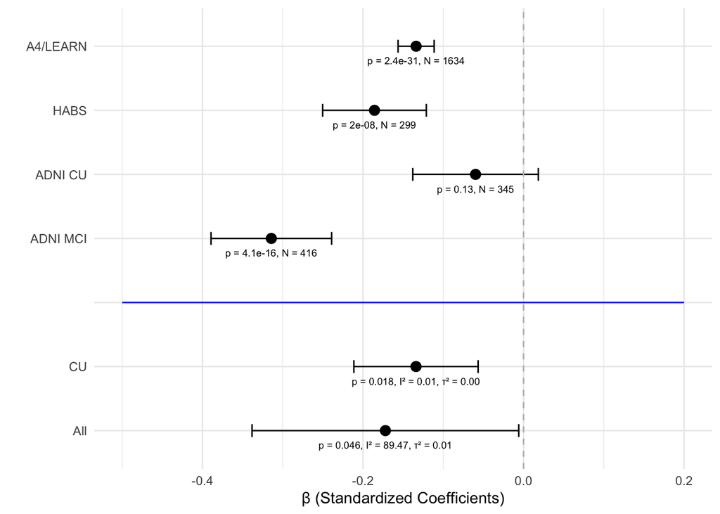

## AB-PET

```
## All Cohorts BrainAge AB-PET effect: -0.092 [ -0.13 , -0.051 ]  p-val: 0.0055  I2: 12.2
```

```
## CU Cohorts BrainAge AB-PET effect: -0.088 [ -0.15 , -0.027 ]  p-val: 0.025  I2: 0
```

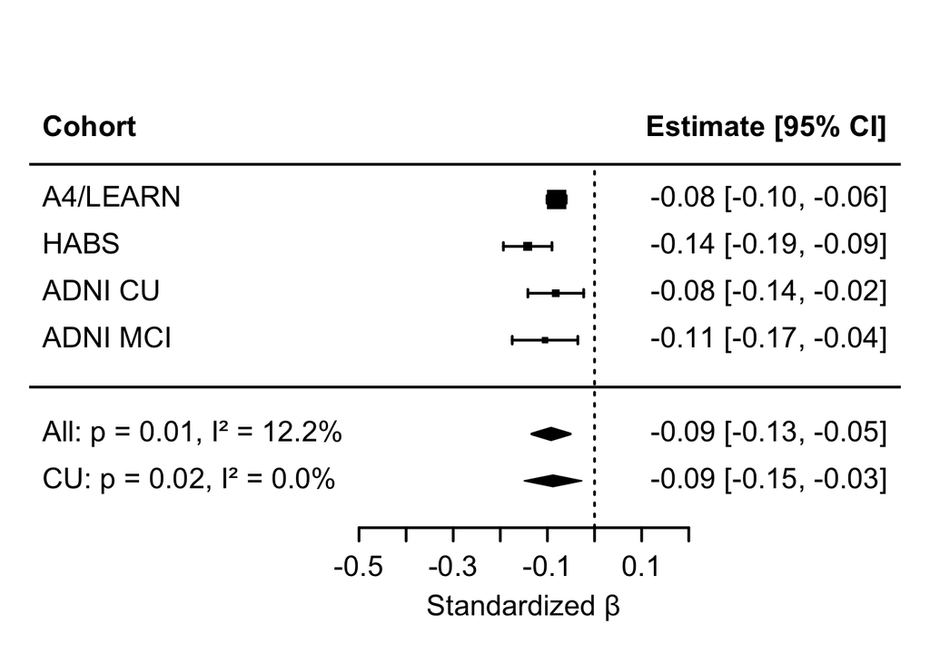

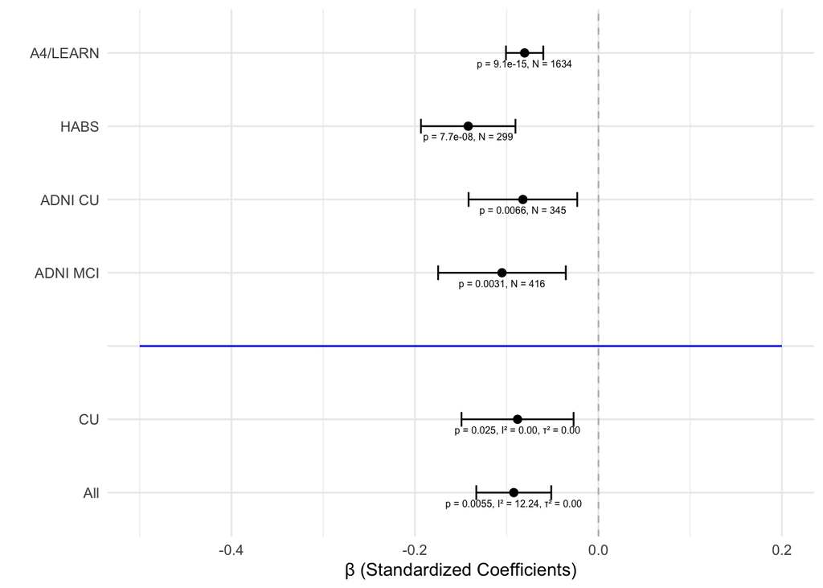

## pTau217

```
## All Cohorts BrainAge pTau217 effect: -0.091 [ -0.15 , -0.03 ]  p-val: 0.018  I2: 0.0761
```

```
## CU Cohorts BrainAge pTau217 effect: -0.086 [ -0.13 , -0.041 ]  p-val: 0.014  I2: 0
```

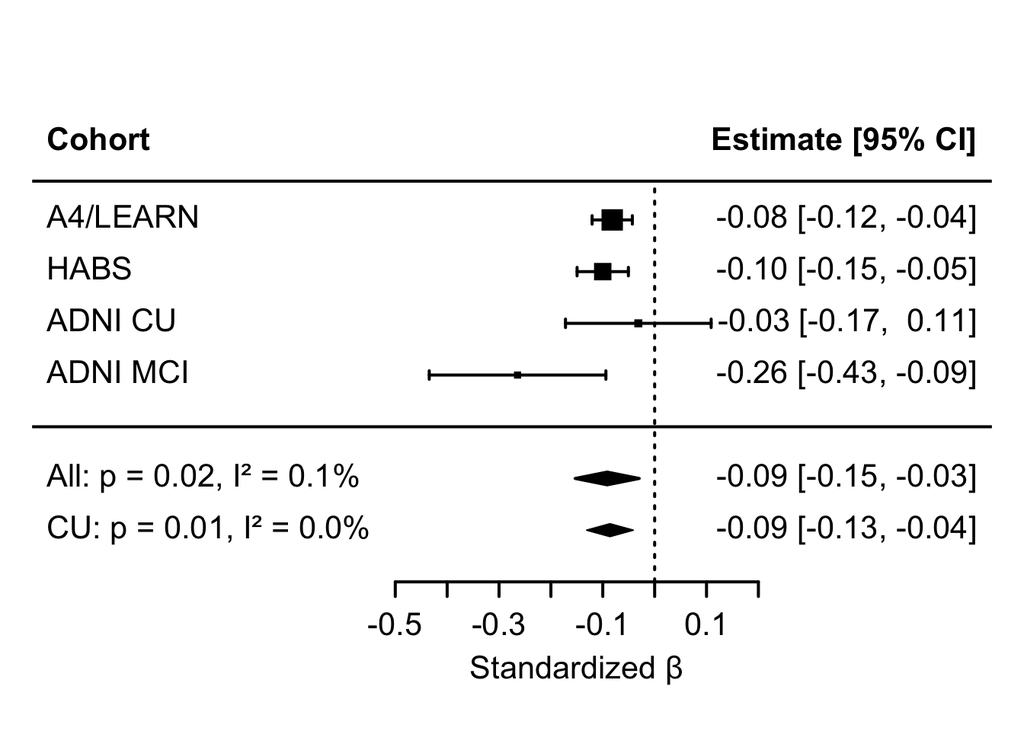

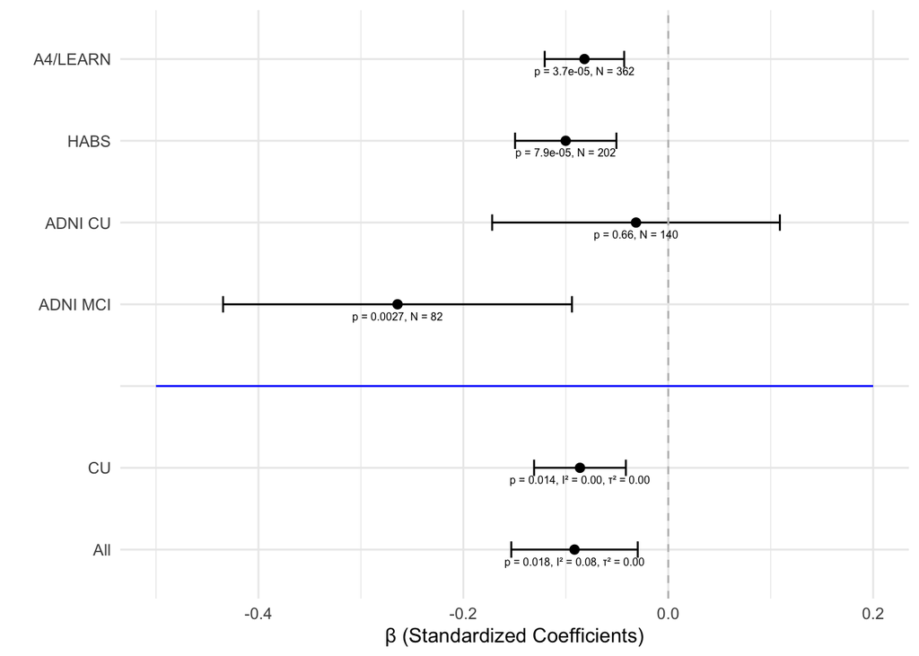

## Tau-PET

```
## All Cohorts BrainAge Tau-PET effect: -0.086 [ -0.22 , 0.05 ]  p-val: 0.14  I2: 73.7
```

```
## CU Cohorts BrainAge Tau-PET effect: -0.076 [ -0.29 , 0.14 ]  p-val: 0.27  I2: 81.2
```

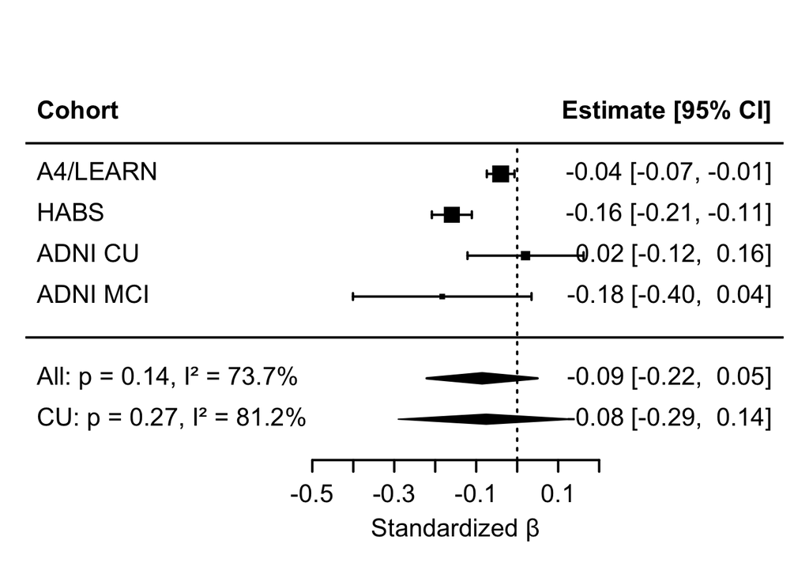

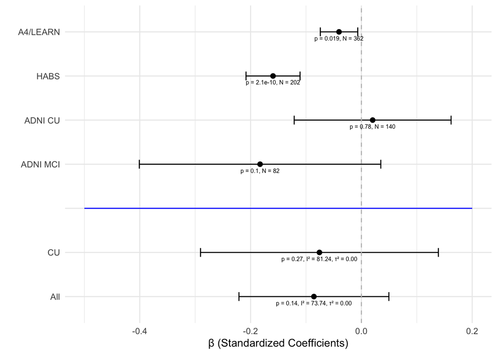

# Extra Analysis

Run all linear mixed effects models from exploratory analysis with all subjects available.

## pTau217

```
## All Cohorts BrainAge pTau217 effect: -0.091 [ -0.13 , -0.056 ]  p-val: 0.0039
```

```
## CU Cohorts BrainAge pTau217 effect: -0.091 [ -0.15 , -0.032 ]  p-val: 0.022
```

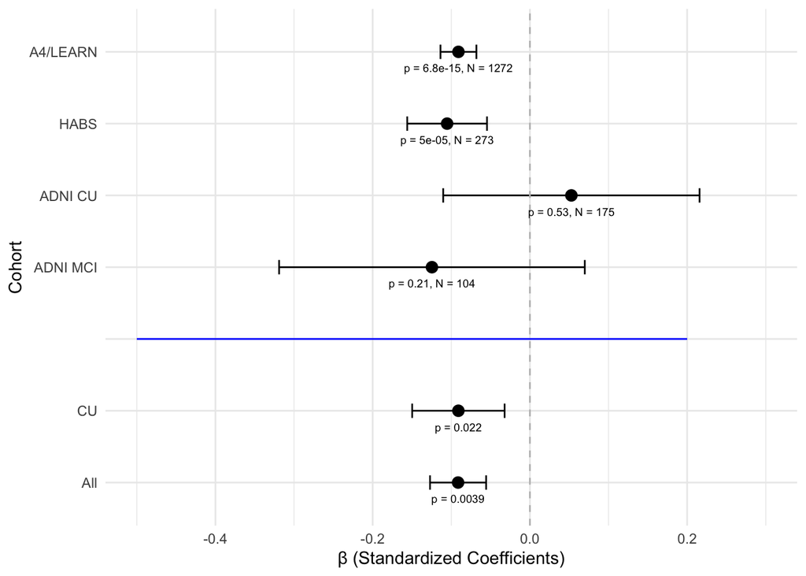

## Tau-PET

```
## All Cohorts BrainAge tau effect: -0.045 [ -0.18 , 0.093 ]  p-val: 0.38
```

```
## CU Cohorts BrainAge tau effect: -0.076 [ -0.26 , 0.11 ]  p-val: 0.22
```

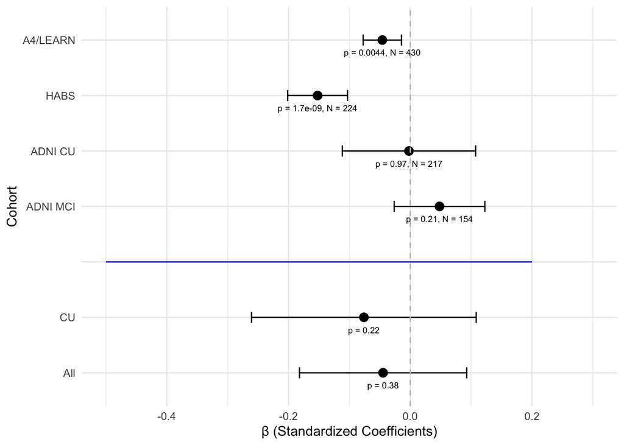